# Exploratory Analysis of Bakery Data

Andrew Whang

October 26, 2018

### Import data and Packages

Load packages, lubridate, dplyr, ggplot2, bindrcpp. Data was found from Kaggle at https://www.kaggle.com/xvivancos/transactions-from-a-bakery

```r
library(lubridate)
library(dplyr)
library(ggplot2)
library(bindrcpp)
df <- read.csv("BreadBasket_DMS.csv")
```

### Date and Time Conversions

Convert Date and Time to proper formats Also add columns for day of the week and the month of the transaction

```r
df$Date <- as.Date(df$Date)
df$Time <- hms(df$Time)
df$weekday <- wday(df$Date, label = TRUE)
df$month <- month(df$Date, label = TRUE)
```

### Note on filters

We also remove items labeled as “NONE” and select the top 15 most sold items

## Exploratory Analysis

### By Item

A plot of which items sell the most.

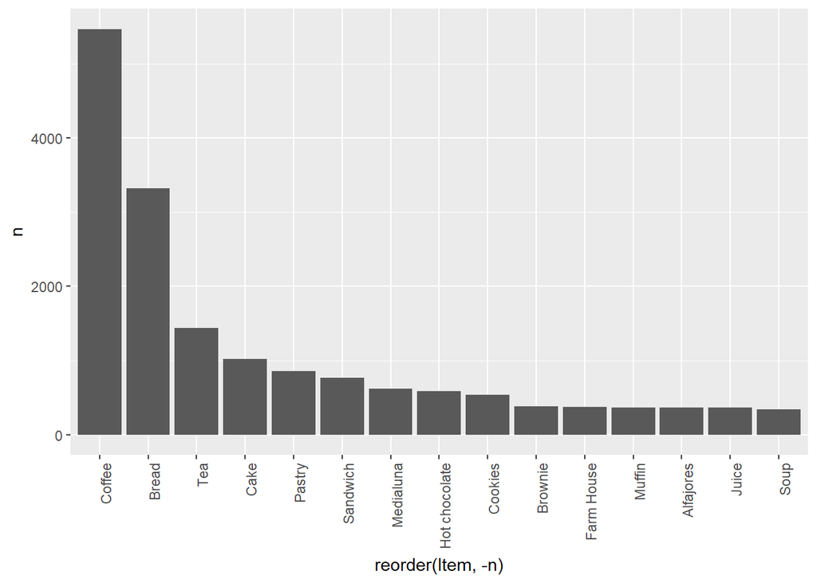

Seems like coffee and bread make up the most items sold

### By day of the week

A plot by day of the week shows Saturday sells the most

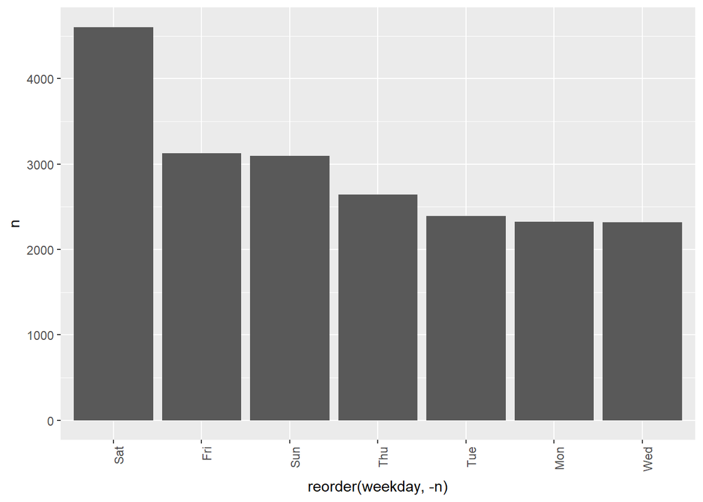

### By day of the week and n item sold

Let’s see if there are any differences in which items are sold based on day of the week for each day the top 6 items are selected.

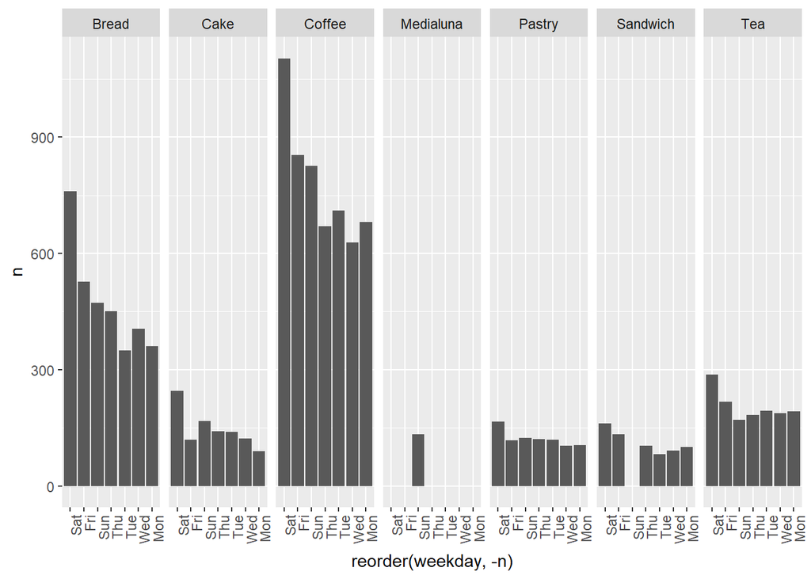

Initially, Medialuna appears only on Sunday as a popular item but later on I discovered this was an issue with the coding which elimated values on months where Medialuna isn’t in the top 6 for that month and possible be the 7th most item sold in that month.

Here is a graph of weekday items sold for ‘top 6’ items, with the items specifically mentioned in a vector where we can run the filter through.

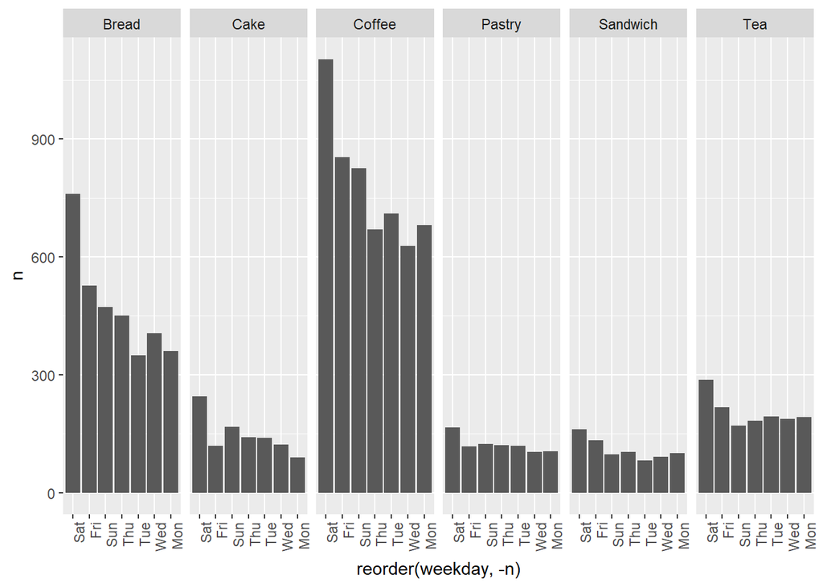

### By month analysis of items sold

I removed April and October since those are the start and end months of data collection which likely caused data to be incomplete for those months.

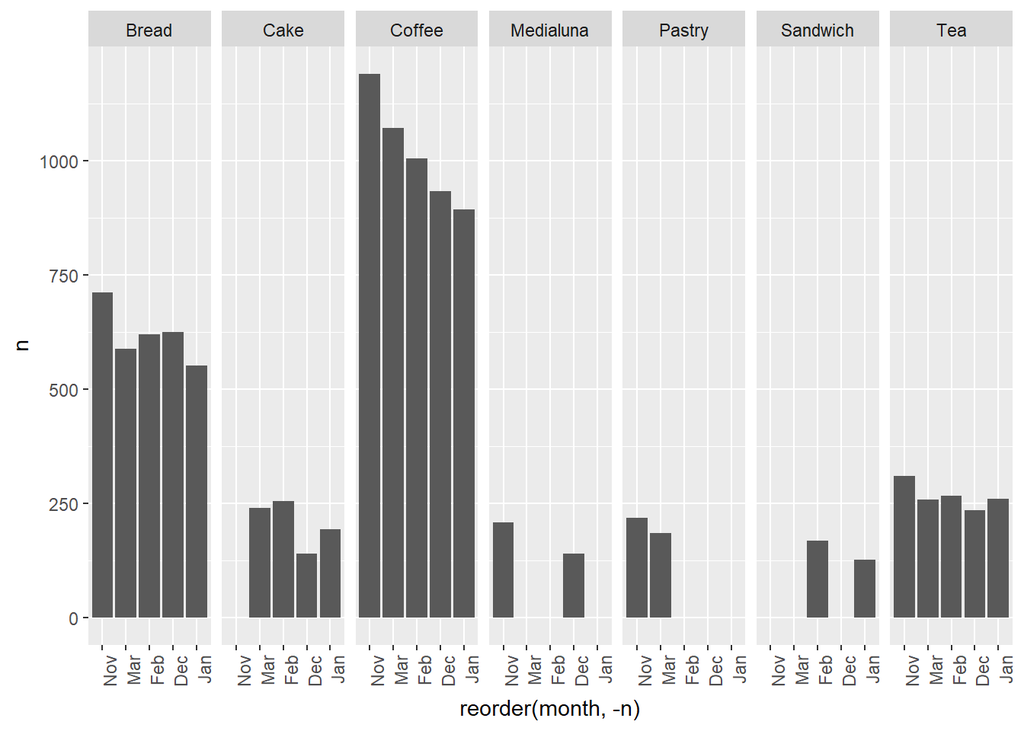

It’s odd that some months have so little sold in Pastry, Sandwhich, and Medialuna Is this observation valid? (This is where I discovered my issue in my coding method)

Let’s graph just medialuna, pastry, and sandwich by month.

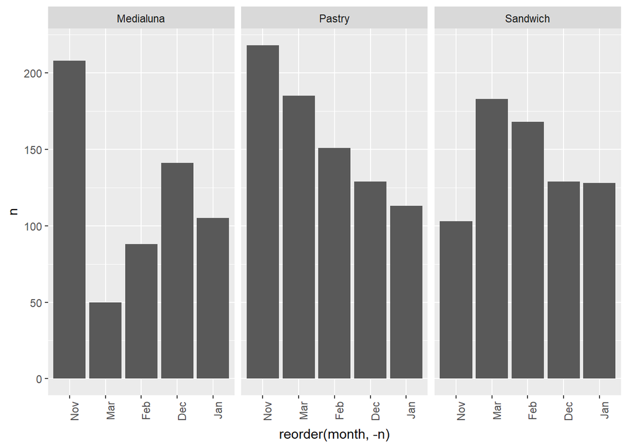

Try to graph all items per month again but filter items specifically, instead of using top_n

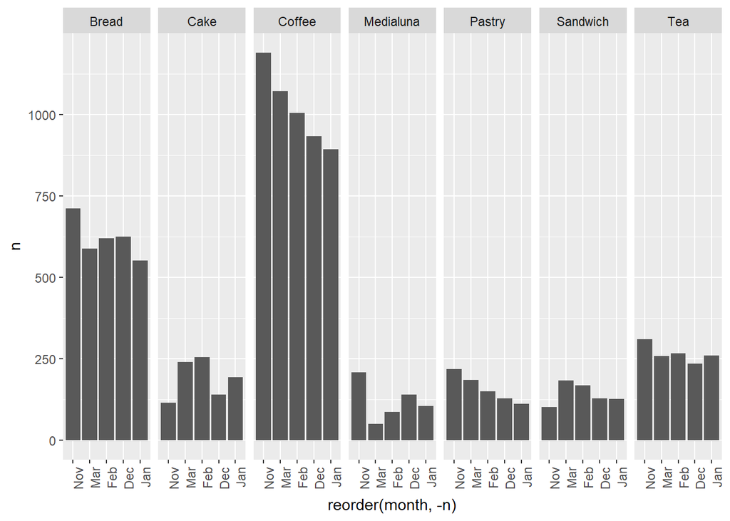

The method of using top_n messes up when a month has a different top_n that others don’t have. Here we accurately see the amounts of each item.